# 2025 IT Prof Conf Data Report

Spencer Bailey

### Conference Registration and Attendance Metrics

#### Daily Registration Counts:

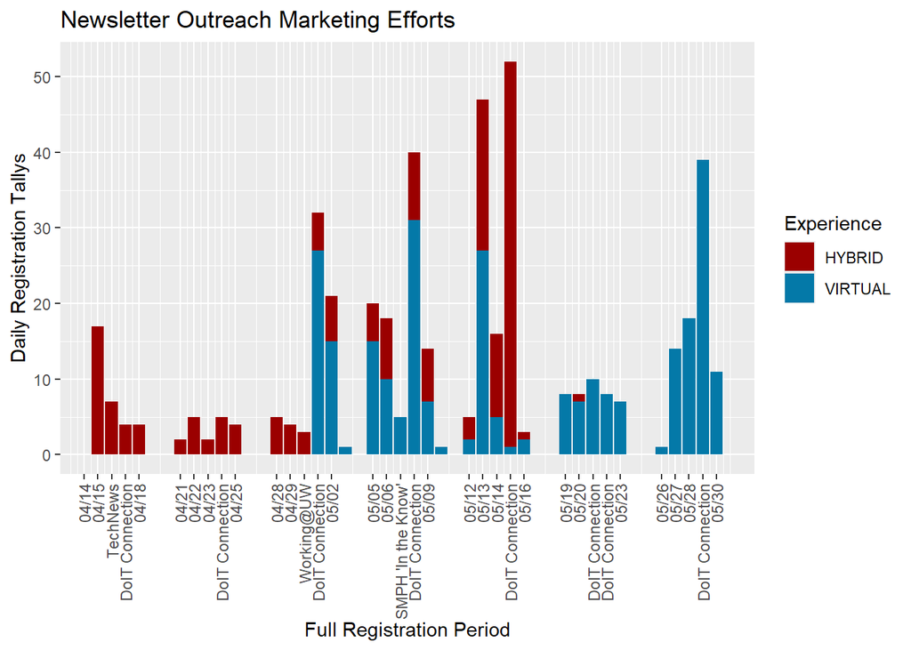

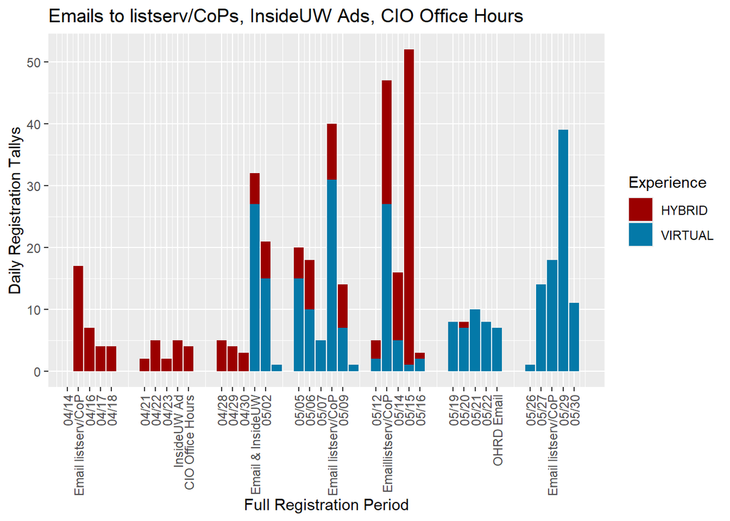

#### Demographic counts for registrants:

These next two charts represent demographic information about conference registrants. The first two charts break down registrants by their School/College/Division. The second two charts breaks registrants down by their position titles. The goal in analyzing demographic data in depth is to get a better sense of who our participants are, so that we might be able to, in future conference planning, identify what our participants might be interested in to drive up our engagement.

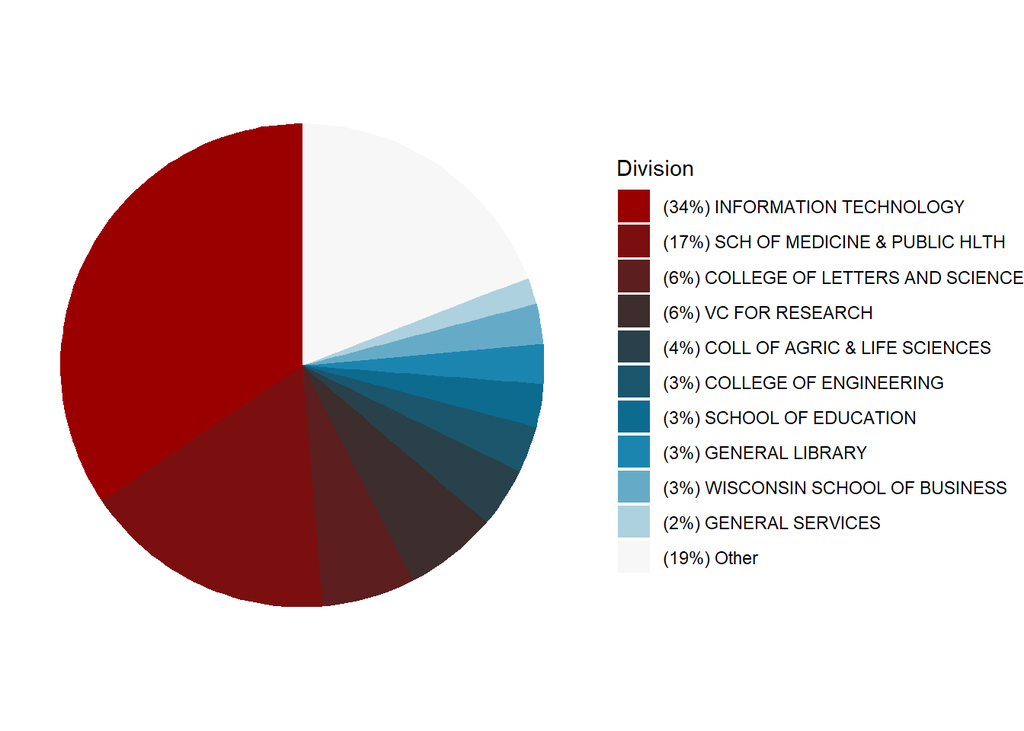

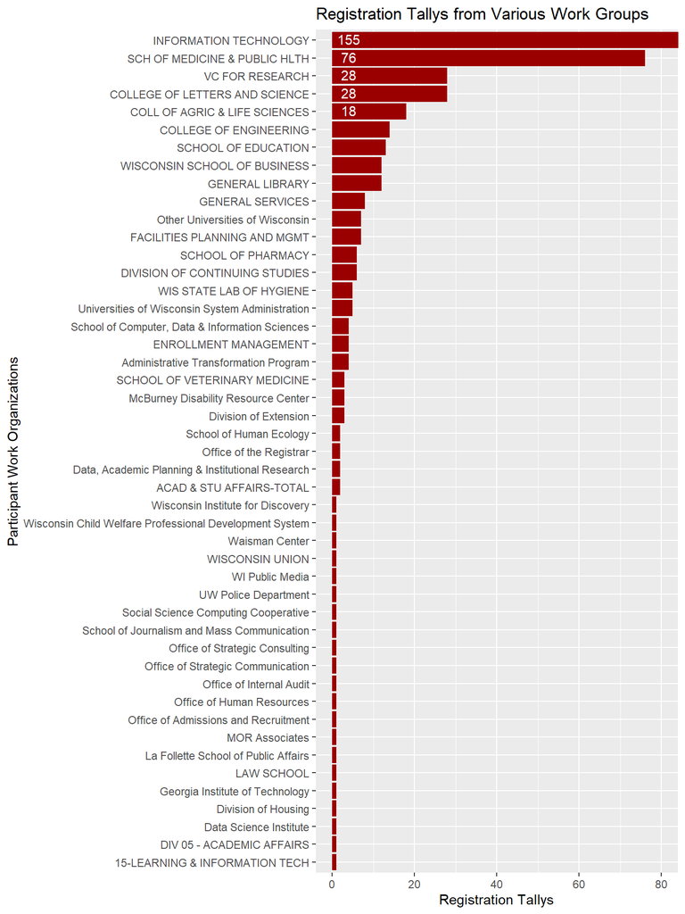

A key observation here is our top 5 represented divisions. DoIT, SMPH, L&S, VCFR and CALS comprised the greatest populations that registered for the conference this year. The top 3 track with our findings during the 2024 IT Professionals Conference as well. Another interesting note is slots 4 & 5 did change from last year. The #4 slot last year was Engineering, and the #5 slot was Research, this year being overtaken by VCFR at #4 and CALS at #5.

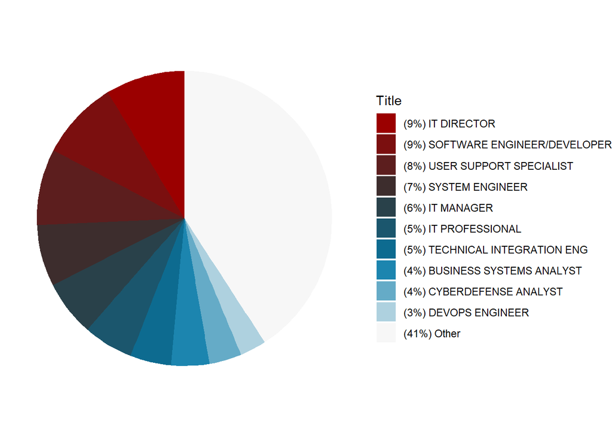

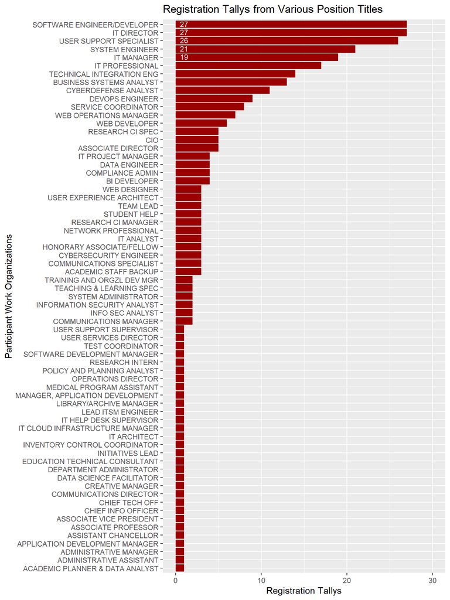

A key observation here is our top 5 represented titles at the conference. Although directors make up a much smaller population of campus employees, they represent the greatest proportion of conference attendees. Software Developers make up another large proportion of conference attendees, as do Support Specialists. Increasing our breadth of content may be able to bring numbers up for smaller represented title groups.

#### Total attendee/registrant counts with comparison to previous year(s):

[output not shown]

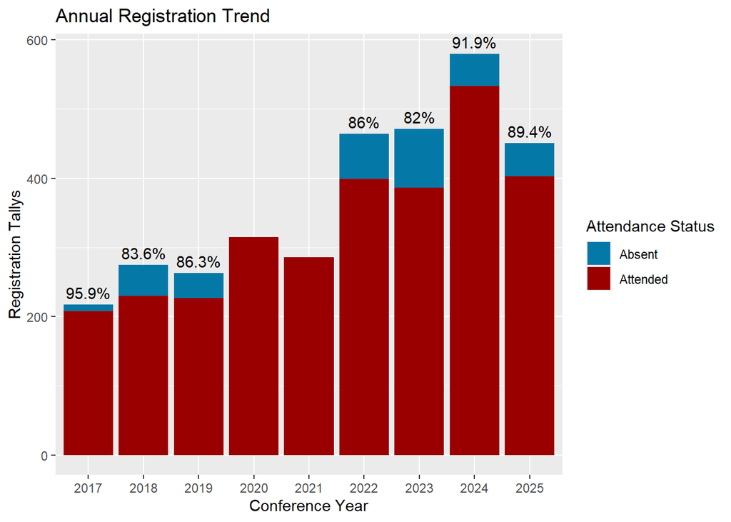

### Session Attendance Metrics

#### Total Attendance Recorded Throughout the Day:

The two following graphs here will portray attendance throughout the day of each conference day, to determine how strongly our attendance counts hold from earlier sessions to later sessions. This insight is valuable as it reveals when peak attendance times are during our conference days.

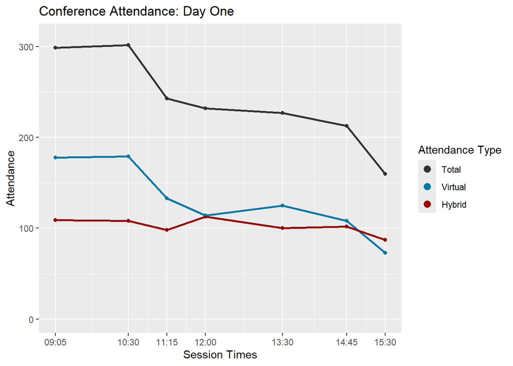

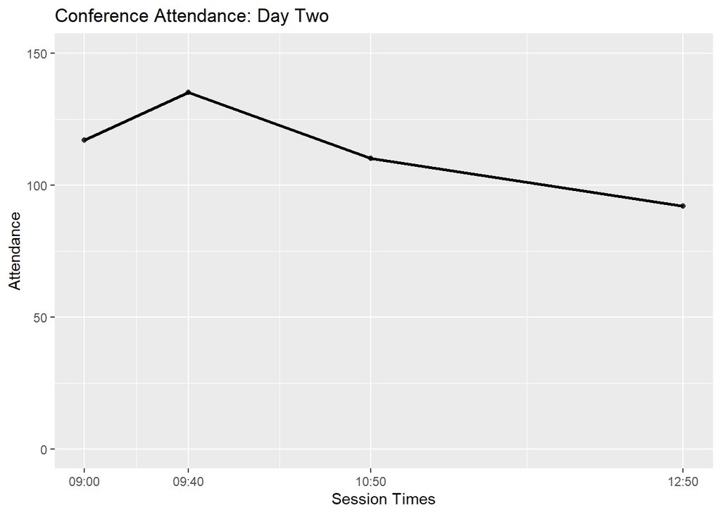

#### Breakdown of Total Attendance Throughout the Day by Session:

| Session Title | Total Attended | Attended Virtual | Attended In-Person |
| --- | --- | --- | --- |
| Welcome and Keynote: Change is the Only Constant | 299 | 178 | 109 |
| It is possible to take down old websites: How WCER manages the website lifecycle | 63 | 32 | 30 |
| Making digital accessibility work: Practical strategies that stick | 86 | 51 | 27 |
| AI in Action: Two Anecdotal Experiences | 153 | 96 | 51 |
| Planned obsolescence: Turning a technology fallacy into a leadership strategy | 69 | 32 | 33 |
| Collaborating in support of RISE | 83 | 48 | 32 |
| Present harms and future risks: A case for responsible AI | 91 | 53 | 33 |
| Empowering expert authors with the KnowledgeBase API | 41 | 22 | 19 |
| Unlocking Potential: Streamlining Processes with Low Code Solutions | 79 | 36 | 40 |
| Countdown to Workday: Hot topics and a peek of what’s to come | 112 | 56 | 54 |
| From the notebook to the cluster | 55 | 40 | 15 |
| IT Connects | 69 | 27 | 41 |
| Flash Talks | 103 | 58 | 44 |
| Virtual Networking | 7 | 7 | 0 |
| Networking | 11 | 0 | 11 |
| Meet the Wisconsin Cyber Response Team | 47 | 21 | 26 |
| Collaborating and planning for AI across the Universities of Wisconsin | 148 | 80 | 65 |
| 2025 IT Recognition Awards Presentation | 160 | 73 | 87 |
| Lessons learnt from upgrading a legacy IICS Secure Agent | 15 | 15 | 0 |
| Redesigning without disruption: Transforming UW-Madison’s KnowledgeBase editor | 43 | 43 | 0 |
| Using vibe programing with AI to transform black and white data into visual dashboards | 59 | 56 | 0 |
| What’s “unconference” and do we need one here? | 29 | 28 | 0 |
| Take the next step in your career with UW-Women in IT | 34 | 32 | 0 |
| Unlock your creative thinking | 72 | 71 | 0 |
| Continuing the conversation: IT Support Symposium virtual meet-up | 14 | 14 | 0 |
| Improving your skills as a technology instructor | 20 | 19 | 0 |
| Getting Started with Gitlab CI, Gitlab Runners and Ansible | 76 | 75 | 0 |
| Networking and games | 20 | 20 | 0 |
| Connecting relationships to results: Enhancing IT and business partnerships | 31 | 31 | 0 |
| Object Storage (S3): Reduce cost and enable new ways to use data | 41 | 41 | 0 |

#### Observations:

The first key observation in the session attendance are our top 5 attended sessions. They keynote had the highest turnout, as it is likely that many were interested in hearing what Lois Brooks had to share with the campus community prior to her retirement. The IT Recognition Awards was the second most attended session, and these follow with what we saw last year with keynote and awards being the top two. Our third place goes to “AI in Action”, fourth to “Collaborating and planning for AI across the Universities of Wisconsin”, and fifth to “Countdown to Workday.”

Another observation made in this data is the decline of participation as the conference carries through the day. It is likely that some people attend only to see our keynote presentations, it is likely that work emergencies or situations take people away from the conference as the day goes on.

A final observation here with the session attendance data is that networking, just as we saw last year, has the lowest turnout for session attendance.

### Financial Reporting

This section will share out the information available in our 2025 Budgeting Sheet.

#### Funds Available for the 2025 IT Professionals Conference

| Budget_Allocation | Registration_Revenue | Total_Budget |
| --- | --- | --- |
| $12,000 | $4,600 | $16,600 |

#### Funds Used for the 2025 IT Professionals Conference

| Facility_Cost | Catering_Cost | Keynote_Speaker_Fee | MISC_Expenses | Captioning | Advertising | Total |
| --- | --- | --- | --- | --- | --- | --- |
| $3,520.00 | $6,030.00 | $0.00 | $342.20 | $0.00 | $600.00 | $10,492 |